# Revised Meta-analysis of Technology-Based Interventions for Loneliness

Jana Furstova & Lukas Novak

2025-12-08

## 1. Setup and Libraries

This chunk loads all necessary R packages for the analysis. The `pimeta` package is used for calculating the robust prediction interval as requested by the reviewer.

```r
library(tidyverse) # For data manipulation (dplyr, etc.)
library(metafor)   # The core package for meta-analysis
library(pimeta)    # For robust prediction intervals (Nagashima method)
library(knitr)     # For report generation
library(kableExtra)# For creating nice HTML tables
```

## 2. Load and Prepare Data

Here, we load the raw data, merge the pre-post correlations, and apply the necessary study exclusions as described in the manuscript.

```r
# Load the two data files
cor_dat <-  readxl::read_xlsx("Data/pre_post_correlations.xlsx")
dat <- read.csv("Data/meta_data.csv")

# This creates a 'Study_name' column in cor_dat that matches the format in the 'dat' file.
cor_dat <- cor_dat %>%
  mutate(Study_name = case_when(
    Author == "Brog et al. (2022)"         ~ "Brog_2022",
    Author == "Hill et al. (2006)"         ~ "Hill_2006",
    Author == "Iyer et al. (2023)"         ~ "Iyer_2023",
    Author == "Karkosz et al. (2024)"      ~ "Karkosz_2024",
    Author == "Robinson et al. (2013)"     ~ "Robinson_2013",
    Author == "Schwindenhammer et al. (2014)" ~ "Schwindenhammer_2014",
    Author == "Shapira et al. (2007)"      ~ "Shapira_2007",
    Author == "Shapira et al. (2021a)"      ~ "Shapira_2021a",
    Author == "Sun (2023)"                 ~ "Sun_2023",
    Author == "Baez et al. (2017)"         ~ "Baez_2017",
    TRUE                                 ~ Author
  ))

# Merge the two datasets using the new, standardized "Study_name" column
analysis_data <- merge(
  dat,
  cor_dat,
  by = "Study_name"
)

# Study Exclusions based on Manuscript Methods
# Exclude studies that are not eligible for the final analysis.
studies_to_exclude <- c("Shapira_2007", "Sun_2023")

analysis_data <- analysis_data %>%
  filter(!Study_name %in% studies_to_exclude)

# Display the final dataset for verification
kable(analysis_data, caption = "Final Dataset for Meta-Analysis") %>%
  kable_styling(bootstrap_options = c("striped", "hover", "condensed"), full_width = F)
```

Final Dataset for Meta-Analysis

| Study_name | Country | Treatment_Pre_Mean | Treatment_Pre_SD | Treatment_post_Mean | Treatment_post_SD | Treatment_Sample_Size | Control_Pre_Mean | Control_Pre_SD | Control_post_Mean | Control_post_SD | Control_sample_size | X | Author | Pre_Post_Correlation_Treatment | Pre_Post_Correlation_Control |
| --- | --- | --- | --- | --- | --- | --- | --- | --- | --- | --- | --- | --- | --- | --- | --- |
| Brog_2022 | Switzerland | 21.26 | 4.82 | 19.88 | 4.56 | 43 | 20.37 | 4.25 | 20.27 | 4.04 | 52 | NA | Brog et al. (2022) | 0.1370926 | 0.9942574 |
| Hill_2006 | USA | 45.73 | 9.99 | 43.15 | 8.69 | 43 | 43.97 | 10.53 | 43.11 | 10.94 | 57 | NA | Hill et al. (2006) | 0.7565056 | 0.9726226 |
| Iyer_2023 | USA | 46.54 | 10.31 | 38.07 | 8.44 | 54 | 43.93 | 10.97 | 42.89 | 11.49 | 54 | NA | Iyer et al. (2023) | 0.0929704 | 0.9914230 |
| Karkosz_2024 | Poland | 45.44 | 12.15 | 43.06 | 13.38 | 40 | 42.39 | 13.25 | 41.49 | 13.42 | 41 | NA | Karkosz et al. (2024) | 0.8038262 | 0.9731696 |
| Robinson_2013 | New Zeland | 36.44 | 9.76 | 32.23 | 9.92 | 17 | 31.71 | 9.50 | 33.93 | 8.52 | 17 | NA | Robinson et al. (2013) | 0.6974001 | 0.9052400 |
| Schwindenhammer_2014 | USA | 17.44 | 4.63 | 14.53 | 4.23 | 40 | 16.45 | 4.66 | 14.13 | 3.88 | 40 | NA | Schwindenhammer et al. (2014) | -0.5401260 | -0.0463396 |
| Shapira_2021a | Israel | 5.40 | 2.00 | 4.80 | 1.70 | 64 | 6.10 | 1.90 | 6.40 | 1.70 | 18 | NA | Shapira et al. (2021a) | 0.4071109 | 0.9613308 |

## 3. Calculate Between-Group Effect Sizes

We calculate the effect size for each study. The chosen measure is `"SMCC"` (Standardized Mean Change using Change Score standardization), which is ideal for a pre-post design with a control group.

```r
# Calculate within-group standardized mean change for the TREATMENT groups
es_treat <- escalc(
  measure = "SMCC",
  m1i = Treatment_post_Mean,   # Post-intervention mean
  m2i = Treatment_Pre_Mean,      # Pre-intervention mean
  sd1i = Treatment_post_SD,     # Post-intervention SD
  sd2i = Treatment_Pre_SD,       # Pre-intervention SD
  ni = Treatment_Sample_Size,    # Sample size
  ri = Pre_Post_Correlation_Treatment, # Pre-post correlation
  data = analysis_data
)

# Calculate within-group standardized mean change for the CONTROL groups
es_ctrl <- escalc(
  measure = "SMCC",
  m1i = Control_post_Mean,
  m2i = Control_Pre_Mean,
  sd1i = Control_post_SD,
  sd2i = Control_Pre_SD,
  ni = Control_sample_size,
  ri = Pre_Post_Correlation_Control,
  data = analysis_data
)

# The final effect size (yi) for the meta-analysis is the difference between the treatment change and the control change.
# The final variance (vi) is the sum of the two variances (as the groups are independent).
analysis_data$yi <- es_treat$yi - es_ctrl$yi
analysis_data$vi <- es_treat$vi + es_ctrl$vi

# Add study labels for plotting
analysis_data$slab <- analysis_data$Study_name
```

## 4. Perform Meta-Analysis

We run the main random-effects model using the `metafor` package. This model provides the pooled effect estimate and heterogeneity statistics (I², Q) used in the manuscript and forest plot.

```r
# Run the robust random-effects model (REML + HKSJ)
# This is the primary model for our manuscript
meta_model <- rma(
  yi, vi,
  data = analysis_data,
  method = "REML", # Restricted Maximum-Likelihood is preferred over DL
  test = "knha",   # Hartung-Knapp-Sidik-Jonkman adjustment
  slab = slab
)

# Display the full summary of the model results
# This output contains the pooled effect, heterogeneity stats (I^2, Q), and significance tests.
summary(meta_model)
```

```
##
## Random-Effects Model (k = 7; tau^2 estimator: REML)
##
##   logLik  deviance       AIC       BIC      AICc
##  -3.2336    6.4672   10.4672   10.0507   14.4672
##
## tau^2 (estimated amount of total heterogeneity): 0.0759 (SE = 0.0774)
## tau (square root of estimated tau^2 value):      0.2755
## I^2 (total heterogeneity / total variability):   57.44%
## H^2 (total variability / sampling variability):  2.35
##
## Test for Heterogeneity:
## Q(df = 6) = 13.6839, p-val = 0.0334
##
## Model Results:
##
## estimate      se     tval  df    pval    ci.lb   ci.ub
##  -0.2101  0.1536  -1.3683   6  0.2202  -0.5859  0.1656
##
## ---
## Signif. codes:  0 '***' 0.001 '**' 0.01 '*' 0.05 '.' 0.1 ' ' 1
```

## 5. Generate Outputs for Manuscript

### 5.1. Data for Manuscript Table 2

This chunk extracts the study-level results into a clean table, exactly as needed for the manuscript. This table provides the core quantitative results for each included study.

```r
# Create a summary data frame of the results
results_table <- summary(meta_model, digits=3)

# Extract the individual study data into a clean table
table_2_data <- data.frame(
    Study      = meta_model$slab,
    SMD        = round(meta_model$yi, 3),
    Std_Error  = round(sqrt(meta_model$vi), 3),
    Variance   = round(meta_model$vi, 3),
    CI_lower   = round(meta_model$yi - qnorm(0.975) * sqrt(meta_model$vi), 3),  # ← FIXED
    CI_upper   = round(meta_model$yi + qnorm(0.975) * sqrt(meta_model$vi), 3),  # ← FIXED
    Z_value    = round(meta_model$yi / sqrt(meta_model$vi), 3),
    P_value    = round(2 * pnorm(abs(meta_model$yi / sqrt(meta_model$vi)),
                                 lower.tail = FALSE), 3)
)

# Print the table in a clean format
kable(table_2_data, row.names = FALSE, caption = "Study-Level Results for Manuscript Table 2") %>%
  kable_styling(bootstrap_options = c("striped", "hover", "condensed"), full_width = F)
```

Study-Level Results for Manuscript Table 2

| Study | SMD | Std_Error | Variance | CI_lower | CI_upper | Z_value | P_value |
| --- | --- | --- | --- | --- | --- | --- | --- |
| Brog_2022 | -0.019 | 0.208 | 0.043 | -0.428 | 0.389 | -0.093 | 0.926 |
| Hill_2006 | -0.049 | 0.209 | 0.043 | -0.457 | 0.360 | -0.234 | 0.815 |
| Iyer_2023 | 0.000 | 0.212 | 0.045 | -0.416 | 0.416 | 0.000 | 1.000 |
| Karkosz_2024 | -0.003 | 0.227 | 0.051 | -0.448 | 0.441 | -0.015 | 0.988 |
| Robinson_2013 | -1.047 | 0.366 | 0.134 | -1.764 | -0.330 | -2.863 | 0.004 |
| Schwindenhammer_2014 | 0.000 | 0.231 | 0.053 | -0.453 | 0.453 | 0.000 | 1.000 |
| Shapira_2021a | -0.824 | 0.282 | 0.080 | -1.378 | -0.271 | -2.919 | 0.004 |

### 5.2. Prediction Interval

The prediction interval shows the expected range of true effects in future studies. This has been updated to use the correct syntax for the `pima` function from the `pimeta` package. The method `"boot"` corresponds to the Nagashima et al. (2019) confidence distribution approach.

```r
# Calculate and print the 95% prediction interval using the Nagashima et al. method.
# The pima() function takes the effect sizes (y) and standard errors (se) as input.
# The `method = "boot"` argument specifies the parametric bootstrap PI, which is the
# confidence distribution approach from Nagashima et al. (2019).
pi_model <- pima(
  y = analysis_data$yi,
  se = sqrt(analysis_data$vi),
  method = "boot", # Explicitly specify the Nagashima et al. method
)

# Print the results, which include the CI and the PI
print(pi_model)
```

```
##
## Prediction & Confidence Intervals for Random-Effects Meta-Analysis
##
## A parametric bootstrap prediction and confidence intervals
##  Heterogeneity variance: DerSimonian-Laird
##  Variance for average treatment effect: Hartung (Hartung-Knapp)
##
## No. of studies: 7
##
## Average treatment effect [95% prediction interval]:
##  -0.2086 [-1.1051, 0.6221]
##  d.f.: 6
##
## Average treatment effect [95% confidence interval]:
##  -0.2086 [-0.6002, 0.1632]
##  d.f.: 6
##
## Heterogeneity measure
##  tau-squared: 0.0720
##  I-squared:  56.2%
```

### 5.3. Forest Plot

This is the primary visualization of the meta-analysis results. The text annotation for the prediction interval has been updated to use the values from the correctly calculated `pi_model` object.

```r
# Forest plot to PDF & SVG
# Adds N(Treatment), N(Control), Weight(%)
# Now includes visual prediction interval diamond (Nagashima method)

# pdf("forest_plot_final.pdf", width = 11, height = 7.5)
svg("forest_plot_final.svg", width = 11, height = 7.5)

k <- meta_model$k
rows_studies <- k:1

# Compute weights (%)
w <- weights(meta_model)
w_perc <- 100 * w / sum(w)

# Build extra columns
ilab_mat <- cbind(
    as.integer(analysis_data$Treatment_Sample_Size),
    as.integer(analysis_data$Control_sample_size),
    sprintf("%.1f", w_perc)
)

# Extract prediction interval values from pimeta
lpi <- if (!is.null(pi_model$lpi)) pi_model$lpi else pi_model$pi.lb
upi <- if (!is.null(pi_model$upi)) pi_model$upi else pi_model$pi.ub

# Forest plot
metafor::forest(
    meta_model,

    # Labels
    xlab   = "Standardized Mean Difference (SMD)",
    header = c("Author(s) and Year", "SMD [95% CI]"),
    mlab   = "REML Model (HKSJ)",
    digits = 2,
    cex    = 1.0,

    # Layout: make room for 3 columns on the left
    alim   = c(-3, 3),
    xlim   = c(-10.5, 3),
    rows   = rows_studies,
    ylim   = c(-3.9, k + 3),

    # Model overlays
    annotate = TRUE,
    addfit   = TRUE,
    addpred  = FALSE,

    # Extra columns
    showweights = FALSE,
    ilab        = ilab_mat,
    ilab.xpos   = c(-7.5, -6.0, -4.5),
    ilab.pos    = 4,
    ilab.lab    = c("N (Treatment)", "N (Control)", "Weight (%)")
)

# Manually add prediction interval diamond (Nagashima method)
# This draws the diamond below the pooled effect diamond
addpoly(x = (lpi + upi)/2,  # Center of the prediction interval
        ci.lb = lpi,         # Lower bound from pimeta
        ci.ub = upi,         # Upper bound from pimeta
        rows = -1.5,         # Changed from -1 to -1.5 for more spacing
        col = "lightgray",   # Fill color
        border = "darkgray", # Border color
        mlab = "Prediction Interval (Nagashima)",  # Label
        cex = 0.9)

# Extra annotations below the plot
par(xpd = NA)
usr <- par("usr")
x_left <- usr[1]

# Heterogeneity
text(
  x = x_left, y = -2.5, pos = 4, cex = 0.9,  # Changed from -1.7 to -2.5
  bquote(paste(
    "Heterogeneity: Q = ", .(round(meta_model$QE, 2)),
    ", df = ", .(meta_model$k - meta_model$p),
    ", p = ", .(format.pval(meta_model$QEp, digits = 2, eps = 0.001)),
    "; ", I^2, " = ", .(round(meta_model$I2, 1)), "%"
  ))
)

dev.off()
```

### 5.4. Publication Bias Analysis

This section remains unchanged and uses the `metafor` model for consistency in bias diagnostics.

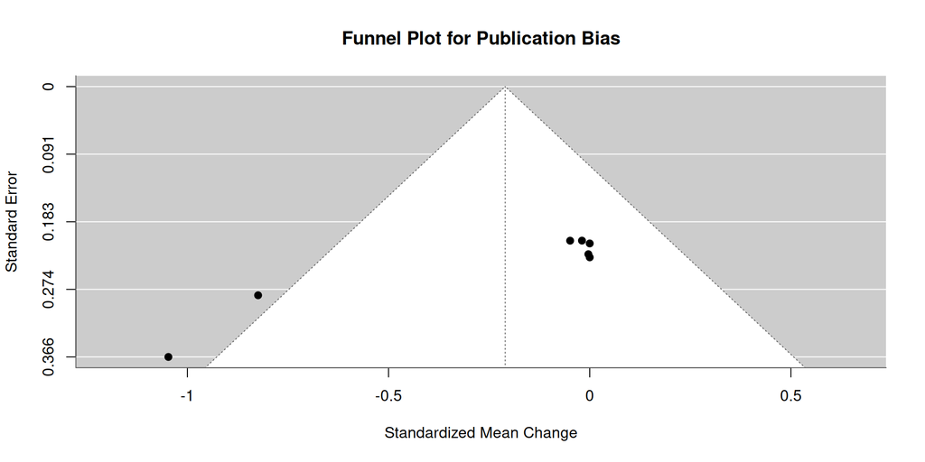

```r
# 1. Funnel Plot
# A symmetric plot suggests no small-study effects (like publication bias)
funnel(meta_model, main = "Funnel Plot for Publication Bias")
```

```r
# 2. Egger's Regression Test
# A non-significant p-value (p > 0.05) suggests no significant funnel plot asymmetry.
reg_test_results <- regtest(meta_model, model = "rma")
print(reg_test_results)
```

```
##
## Regression Test for Funnel Plot Asymmetry
##
## Model:     mixed-effects meta-regression model
## Predictor: standard error
##
## Test for Funnel Plot Asymmetry: t = -5.4678, df = 5, p = 0.0028
## Limit Estimate (as sei -> 0):   b =  1.6177 (CI: 0.7714, 2.4641)
```

```r
# 3. Trim and Fill Analysis
# This method estimates the number of potentially missing studies and the adjusted pooled effect.
trimfill_results <- trimfill(meta_model)
summary(trimfill_results)
```

```
##
## Estimated number of missing studies on the right side: 0 (SE = 1.7467)
##
## Random-Effects Model (k = 7; tau^2 estimator: REML)
##
##   logLik  deviance       AIC       BIC      AICc
##  -3.2336    6.4672   10.4672   10.0507   14.4672
##
## tau^2 (estimated amount of total heterogeneity): 0.0759 (SE = 0.0774)
## tau (square root of estimated tau^2 value):      0.2755
## I^2 (total heterogeneity / total variability):   57.44%
## H^2 (total variability / sampling variability):  2.35
##
## Test for Heterogeneity:
## Q(df = 6) = 13.6839, p-val = 0.0334
##
## Model Results:
##
## estimate      se     tval  df    pval    ci.lb   ci.ub
##  -0.2101  0.1536  -1.3683   6  0.2202  -0.5859  0.1656
##
## ---
## Signif. codes:  0 '***' 0.001 '**' 0.01 '*' 0.05 '.' 0.1 ' ' 1
```

### 5.5. Sensitivity Analysis (Leave-One-Out)

This analysis recalculates the pooled effect by removing one study at a time to see if any single study disproportionately influences the overall result. This section also remains unchanged and uses the `metafor` model.

```r
# Perform and print the leave-one-out analysis
leave1out_results <- leave1out(meta_model)
print(leave1out_results)
```

```
##
##                       estimate     se    tval   pval   ci.lb  ci.ub       Q
## -Brog_2022             -0.2597 0.1826 -1.4221 0.2143 -0.7292 0.2098 13.1531
## -Hill_2006             -0.2552 0.1842 -1.3852 0.2246 -0.7288 0.2184 13.3565
## -Iyer_2023             -0.2620 0.1813 -1.4452 0.2080 -0.7281 0.2040 13.0235
## -Karkosz_2024          -0.2596 0.1811 -1.4333 0.2112 -0.7252 0.2060 13.1446
## -Robinson_2013         -0.1016 0.1120 -0.9073 0.4058 -0.3895 0.1863  7.3817
## -Schwindenhammer_2014  -0.2595 0.1808 -1.4353 0.2107 -0.7242 0.2053 13.1444
## -Shapira_2021a         -0.0831 0.1146 -0.7248 0.5010 -0.3776 0.2115  7.4758
##                           Qp   tau2      I2     H2
## -Brog_2022            0.0220 0.1122 65.4427 2.8937
## -Hill_2006            0.0203 0.1157 66.1451 2.9538
## -Iyer_2023            0.0232 0.1094 65.0448 2.8608
## -Karkosz_2024         0.0221 0.1097 65.6653 2.9125
## -Robinson_2013        0.1938 0.0015  2.9026 1.0299
## -Schwindenhammer_2014 0.0221 0.1091 65.7086 2.9162
## -Shapira_2021a        0.1876 0.0000  0.0025 1.0000
```

# References:

Nagashima, K., Noma, H., & Furukawa, T. A. (2019). Prediction intervals for random-effects meta-analysis: a confidence distribution approach. Statistical methods in medical research, 28(6), 1689-1702.